# clinical data practice

> This practice works on a dataset of the following research:  
> [doi:10.1016/j.nutres.2018.12.004](https://doi.org/10.1016/j.nutres.2018.12.004)

This research tested the effect of ingesting encapsulated lipid beads on subsequent food intake of overweight adults. The experiment adopted a randomized placebo-controlled crossover design.

Two groups of adults were treated with either yogurt containing encapsulated lipid beads (**active group**) or yogurt with non-encapsulated nutrient (**placebo/control group**) before an *ad libitum* pasta meal. After a week of washout period, each of the two subject groups was treated with one of the other experimental treatment. The experiment data can be found on [Mendeley Data](https://data.mendeley.com/datasets/hxyx3vdf3b/1).

### Load cleaned datasets

```r
source ("./clinical_data_practice.R")
```

### Overview of datasets

##### The first dataset contains basic subject description and food consumption. The calories of pasta consumed by the subjects in each *ad libtum* session were recorded after each treatment. Each subject experienced 2 treatments, in different order, across 2 time points. Therefore, each subject generated 2 data points, the calories taken after an active treatment (**activeIntake_kcal**), and those after a control treatment (**controlIntake_kcal**).

```r
str (dat1)
## 'data.frame':    33 obs. of  11 variables:
##  $ id                : chr  "LE01" "LE02" "LE03" "LE04" ...
##  $ activeBefore_g    : num  1726 1712 1779 1772 1769 ...
##  $ activeAfter_g     : num  1405 1290 1462 1190 1309 ...
##  $ controlBefore_g   : num  1779 1757 1736 1771 1709 ...
##  $ controlAfter_g    : num  1447 1296 1388 1154 1180 ...
##  $ age               : num  26 19 45 42 22 21 64 60 28 64 ...
##  $ gender            : num  2 2 2 2 2 2 1 1 1 1 ...
##  $ bmi               : num  28.3 28.4 29.3 28.2 28.9 ...
##  $ first_intervention: num  1 2 2 1 2 1 1 2 2 1 ...
##  $ activeIntake_kcal : num  489 642 481 885 699 ...
##  $ controlIntake_kcal: num  505 701 528 938 803 ...
```

##### The second dataset contains measurements of subject satiaty and unpleasant GI symptoms

```r
str (dat2)
## 'data.frame':    395 obs. of  20 variables:
##  $ ID                     : chr  "LE1" "LE1" "LE1" "LE1" ...
##  $ Time                   : num  0 30 60 90 105 120 135 150 165 180 ...
##  $ Satiety-active         : num  19 69 35.5 42 67 66 64.5 71 72 64 ...
##  $ Hunger-active          : num  82 42 42 48.5 18.5 19 36.5 30.5 31 17 ...
##  $ Desire.to.eat-active   : num  73 39 43 58.5 13 24.5 25 19 35 22 ...
##  $ Desire.to.snack-active : num  28 17.5 24.5 23.5 28 41 31 25 16 10 ...
##  $ Fullness-active        : num  16 23 29 29.5 64.5 58 49.5 62 66 53 ...
##  $ Bloating-active        : num  4.5 7 7 9 0 0 0 0 0 0 ...
##  $ Discomfort-active      : num  66 13 13 9 0 0 14 11.5 11 3.5 ...
##  $ Pain-active            : num  0 0 0 0 0 0 0 0 0 0 ...
##  $ Nausea-active          : num  16 0 0 0 0 0 0 0 0 0 ...
##  $ Satiety-control        : num  9 56 64 67 77 81 75 82.5 78 76.5 ...
##  $ Hunger-control         : num  92 19.5 36 59.5 18.5 18 18.5 11 11.5 8 ...
##  $ Desire.to.eat-control  : num  98 67 36 71.5 14 25 24 10 11 11 ...
##  $ Desire.to.snack-control: num  20 80 50.5 62 28.5 36 31 16 18.5 14.5 ...
##  $ Fullness-control       : num  0 39.5 43 35.5 75.5 64 68 82 74 73.5 ...
##  $ Bloating-control       : num  20 17 0 0 5 9 0 0 0 0 ...
##  $ Discomfort-control     : num  20.5 17 0 0 0 0.5 0 0.5 1 0 ...
##  $ Pain-control           : num  0 0 0 0 0.5 0 0.5 0 0.5 0 ...
##  $ Nausea-control         : num  0 0 0 0 0 0 0.5 0 0 0 ...
```

### First research question: do subjects treated with encapsulated lipid beads consume less food than subjects treated with non-encapsulated beads?

##### Paired-t test was used to comapare controlIntake_kcal and activeIntake_kcal

```r
ttest <- t.test (x = dat1$controlIntake_kcal, y = dat1$activeIntake_kcal, paired = TRUE)

ttest$p.value
```

```
## [1] 0.01615907
```

##### The answer is yes. Subjects’ consumption is significantly lower in active treatment than that in control treatment.

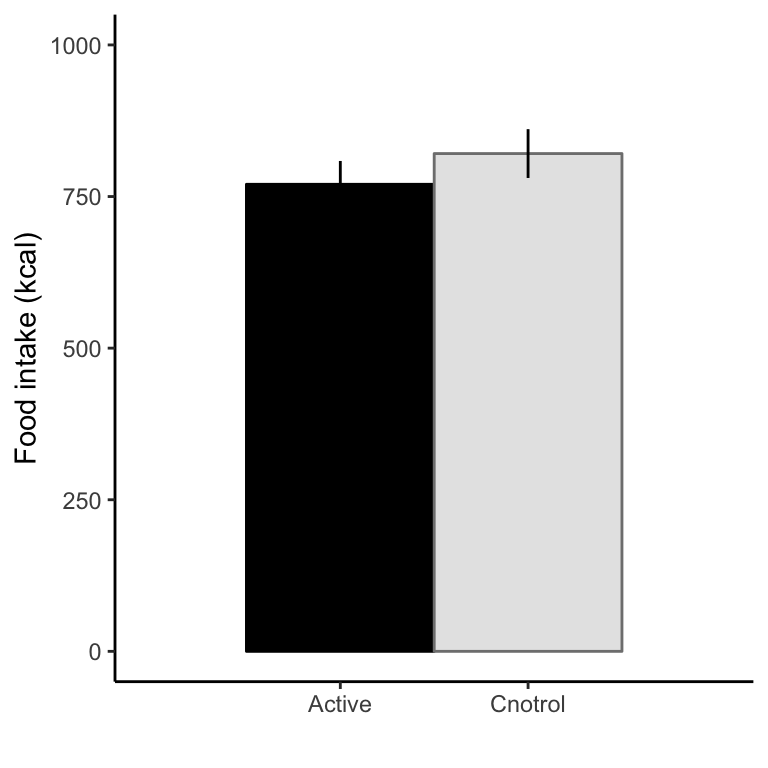

```r
library (ggplot2)
dat1p <- dat1 %>%
  select (controlIntake_kcal, activeIntake_kcal) %>%
  gather (key = key, value = value) %>%
  group_by (key) %>%
  summarise (mean = mean(value),
             sem = sd(value)/sqrt(length(value)))

ggplot (dat1p, aes (x = key, y = mean, fill = key)) +
  geom_bar (stat = "identity", width = 1, position ="dodge", aes (color = key, fill = key)) +
  geom_linerange (aes (ymin = mean - sem, ymax = mean + sem)) +
  scale_color_manual (values = c ("activeIntake_kcal" = "black", "controlIntake_kcal" = "grey50")) +
  scale_fill_manual (values = c ("activeIntake_kcal" = "black", "controlIntake_kcal" = "grey90")) +
  scale_x_discrete(expand = c(0.6,0.6), labels = c ("activeIntake_kcal" = "Active", "controlIntake_kcal" = "Cnotrol")) +
  scale_y_continuous (limits = c(0, 1000)) +
  labs (x = "", y = "Food intake (kcal)") +
  theme_classic () +
  theme (legend.position = "none")
```

### The second question asks whether subjects in active treatment have more desire to eat than in control treatment.

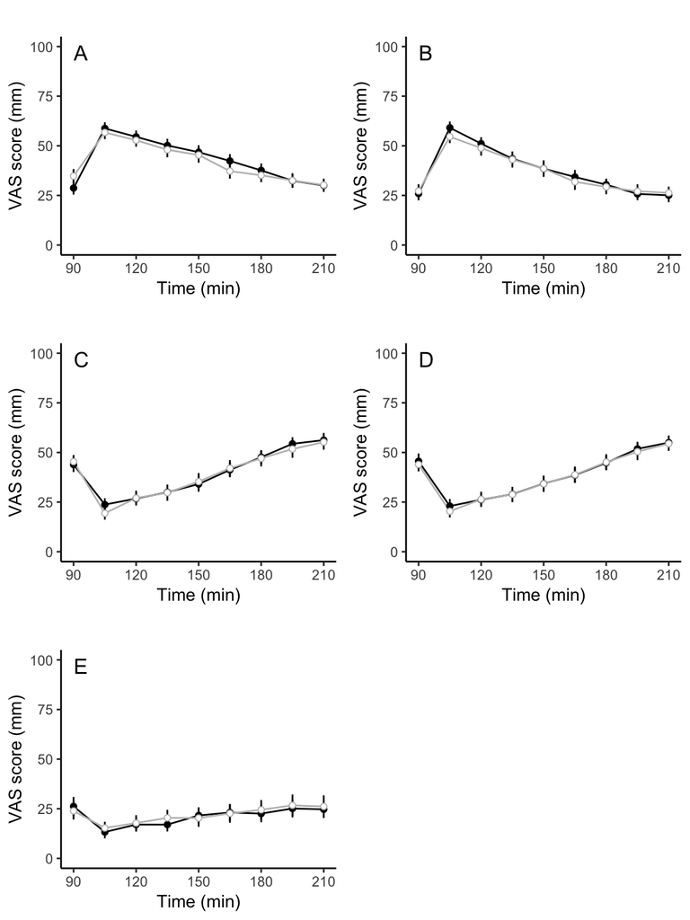

```r
dat2p <- dat2 %>%
  select (Time,
          `Satiety-active`, `Satiety-control`, "Fullness-active", "Fullness-control",
          "Hunger-active", "Hunger-control", `Desire.to.eat-active`, `Desire.to.eat-control`,
          `Desire.to.snack-active`, `Desire.to.snack-control`) %>%
  filter (Time >= 90) %>%
  gather (key, value, -Time) %>%
  separate(key, c("var", "group"), "-") %>%
  group_by(var, group, Time) %>%
  summarize (mean = mean (value),
             sem = sd(value)/sqrt(length(value)))

multiPlot <- function (data, title){

  ggplot (data, aes (x = Time, y = mean, group = group)) +
    geom_linerange (aes (ymin = mean - sem, ymax = mean + sem)) +
    geom_line (aes (color = group)) +
    geom_point (shape = 21, aes (color = group, fill = group)) +
    scale_color_manual(values = c("active" = "black", "control" = "grey"))+
    scale_fill_manual (values = c("active" = "black", "control" = "white")) +
    labs (x = "Time (min)", y = "VAS score (mm)") +
    scale_y_continuous(limits = c(0,100)) +
    ggtitle (title) +
    theme_classic()+
    theme(legend.position='none',
          plot.title = element_text(hjust = 0.05, vjust = -8))

  }
#multiPlot ("Satiety", "A")
A <- multiPlot (dat2p %>% filter (var == "Satiety"), "A")
B <- multiPlot (dat2p %>% filter (var == "Fullness"), "B")
C <- multiPlot (dat2p %>% filter (var == "Hunger"), "C")
D <- multiPlot (dat2p %>% filter (var == "Desire.to.eat"), "D")
E <- multiPlot (dat2p %>% filter (var == "Desire.to.snack"), "E")

library (gridExtra)
grid.arrange (A,B,C,D,E)
```

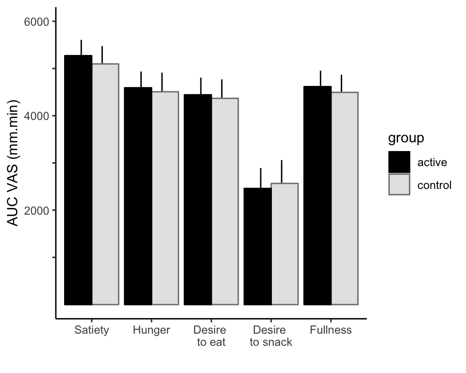

```r
library (pracma)
datAUC <- dat2 %>%
  select (ID, Time,
          `Satiety-active`, `Satiety-control`, "Fullness-active", "Fullness-control",
          "Hunger-active", "Hunger-control", `Desire.to.eat-active`, `Desire.to.eat-control`,
          `Desire.to.snack-active`, `Desire.to.snack-control`) %>%
  filter (Time >= 90) %>%
  gather (key, value, -ID, -Time) %>%
  separate (key, c("var", "group"), "-") %>%
  group_by (ID, var, group) %>%
  summarize (auc = trapz (Time, value))

dat3p <- datAUC %>%
  group_by(var, group) %>%
  summarize (mean = mean (auc),
             sem = sd(auc)/sqrt (length(auc)))


level_order <- factor (dat3p$var, levels = c("Satiety", "Hunger", "Desire.to.eat", "Desire.to.snack", "Fullness"))

ggplot (dat3p, aes (x = level_order, y = mean, group = group, fill = group)) +
  geom_linerange (position = position_dodge(width = 0.7),aes (ymin = mean - sem, ymax = mean + sem)) +
  geom_bar (stat = "identity", position = position_dodge(), aes(color = group)) +
  scale_color_manual (values = c("black", "grey50")) +
  scale_fill_manual (values = c("black", "grey90")) +
  scale_x_discrete (labels = c ("Satiety", "Hunger", "Desire \nto eat", "Desire \nto snack", "Fullness")) +
  scale_y_continuous(limits = c(0,6000), breaks = c (1000, 2000, 3000, 4000, 5000, 6000), labels = c ("", 2000, "", 4000, "", 6000)) +
  labs (x = "", y = "AUC VAS (mm.min)") +
  theme_classic()
```

```r
datAUC <- datAUC %>%
  spread (group, auc) %>%
  arrange (desc(var))

t.test (x = datAUC$control [which (datAUC$var == "Satiety")], y = datAUC$active [which (datAUC$var == "Satiety")], paired = TRUE)

t.test (x = datAUC$control [which (datAUC$var == "Hunger")], y = datAUC$active [which (datAUC$var == "Hunger")], paired = TRUE)

t.test (x = datAUC$control [which (datAUC$var == "Desire.to.eat")], y = datAUC$active [which (datAUC$var == "Desire.to.eat")], paired = TRUE)

t.test (x = datAUC$control [which (datAUC$var == "Desire.to.snack")], y = datAUC$active [which (datAUC$var == "Desire.to.snack")], paired = TRUE)

t.test (x = datAUC$control [which (datAUC$var == "Fullness")], y = datAUC$active [which (datAUC$var == "Fullness")], paired = TRUE)
```

```
##
##  Paired t-test
##
## data:  datAUC$control[which(datAUC$var == "Satiety")] and datAUC$active[which(datAUC$var == "Satiety")]
## t = -0.61013, df = 32, p-value = 0.5461
## alternative hypothesis: true difference in means is not equal to 0
## 95 percent confidence interval:
##  -758.7503  408.9776
## sample estimates:
## mean of the differences
##               -174.8864
##
##
##  Paired t-test
##
## data:  datAUC$control[which(datAUC$var == "Hunger")] and datAUC$active[which(datAUC$var == "Hunger")]
## t = -0.26544, df = 32, p-value = 0.7924
## alternative hypothesis: true difference in means is not equal to 0
## 95 percent confidence interval:
##  -738.2705  568.0432
## sample estimates:
## mean of the differences
##               -85.11364
##
##
##  Paired t-test
##
## data:  datAUC$control[which(datAUC$var == "Desire.to.eat")] and datAUC$active[which(datAUC$var == "Desire.to.eat")]
## t = -0.22783, df = 32, p-value = 0.8212
## alternative hypothesis: true difference in means is not equal to 0
## 95 percent confidence interval:
##  -746.6796  596.4524
## sample estimates:
## mean of the differences
##               -75.11364
##
##
##  Paired t-test
##
## data:  datAUC$control[which(datAUC$var == "Desire.to.snack")] and datAUC$active[which(datAUC$var == "Desire.to.snack")]
## t = 0.47294, df = 32, p-value = 0.6395
## alternative hypothesis: true difference in means is not equal to 0
## 95 percent confidence interval:
##  -352.1180  565.0725
## sample estimates:
## mean of the differences
##                106.4773
##
##
##  Paired t-test
##
## data:  datAUC$control[which(datAUC$var == "Fullness")] and datAUC$active[which(datAUC$var == "Fullness")]
## t = -0.37774, df = 32, p-value = 0.7081
## alternative hypothesis: true difference in means is not equal to 0
## 95 percent confidence interval:
##  -778.7051  535.0687
## sample estimates:
## mean of the differences
##               -121.8182
```

##### No, the levels of satiety, hunger, desire to eat, desire to snack, or fullness did not differ significantly between treatments

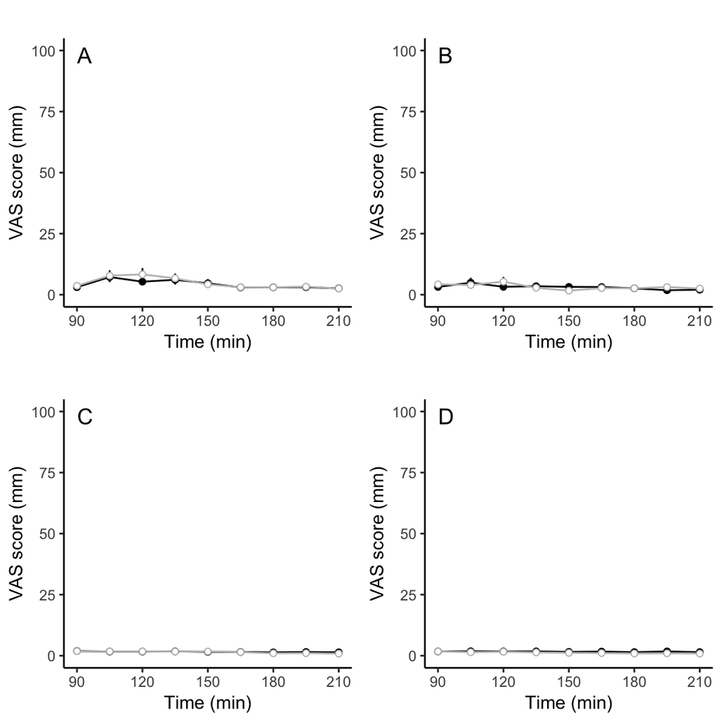

```r
dat4p <- dat2 %>%
  select (Time,
          `Bloating-active`, `Bloating-control`,
          `Discomfort-active`, `Discomfort-control`,
          `Pain-active`, `Pain-control`,
          `Nausea-active`, `Nausea-control`) %>%
  filter (Time >= 90) %>%
  gather (key, value, -Time) %>%
  separate(key, c("var", "group"), "-") %>%
  group_by(var, group, Time) %>%
  summarize (mean = mean (value),
             sem = sd(value)/sqrt(length(value)))

A <- multiPlot (dat4p %>% filter (var == "Bloating"), "A")
B <- multiPlot (dat4p %>% filter (var == "Discomfort"), "B")
C <- multiPlot (dat4p %>% filter (var == "Pain"), "C")
D <- multiPlot (dat4p %>% filter (var == "Nausea"), "D")

grid.arrange(A,B,C,D)
```

```r
datAUC <- dat2 %>%
   select (ID, Time,
          `Bloating-active`, `Bloating-control`,
          `Discomfort-active`, `Discomfort-control`,
          `Pain-active`, `Pain-control`,
          `Nausea-active`, `Nausea-control`) %>%
  filter (Time >= 90) %>%
  gather (key, value, -ID, -Time) %>%
  separate (key, c("var", "group"), "-") %>%
  group_by (ID, var, group) %>%
  summarize (auc = trapz (Time, value)) %>%
  spread (group, auc) %>%
  arrange (var)

wilcox.test (x = datAUC$control [which (datAUC$var == "Bloating")], y = datAUC$active [which (datAUC$var == "Bloating")], paired = TRUE)

wilcox.test (x = datAUC$control [which (datAUC$var == "Discomfort")], y = datAUC$active [which (datAUC$var == "Discomfort")], paired = TRUE)

wilcox.test (x = datAUC$control [which (datAUC$var == "Pain")], y = datAUC$active [which (datAUC$var == "Pain")], paired = TRUE)

wilcox.test (x = datAUC$control [which (datAUC$var == "Nausea")], y = datAUC$active [which (datAUC$var == "Nausea")], paired = TRUE)
```

```
##
##  Wilcoxon signed rank test with continuity correction
##
## data:  datAUC$control[which(datAUC$var == "Bloating")] and datAUC$active[which(datAUC$var == "Bloating")]
## V = 222.5, p-value = 0.9225
## alternative hypothesis: true location shift is not equal to 0
##
##
##  Wilcoxon signed rank test with continuity correction
##
## data:  datAUC$control[which(datAUC$var == "Discomfort")] and datAUC$active[which(datAUC$var == "Discomfort")]
## V = 227.5, p-value = 0.5846
## alternative hypothesis: true location shift is not equal to 0
##
##
##  Wilcoxon signed rank test with continuity correction
##
## data:  datAUC$control[which(datAUC$var == "Pain")] and datAUC$active[which(datAUC$var == "Pain")]
## V = 126.5, p-value = 0.5109
## alternative hypothesis: true location shift is not equal to 0
##
##
##  Wilcoxon signed rank test with continuity correction
##
## data:  datAUC$control[which(datAUC$var == "Nausea")] and datAUC$active[which(datAUC$var == "Nausea")]
## V = 144, p-value = 0.4308
## alternative hypothesis: true location shift is not equal to 0
```

##### None of the GI symptoms differed significantly between groups